# Project 3a

This is the first part of the project. We will be exploring different kinds of methods to apply to our dataset.

## Submission Details

**Project is due June 13th at 11:59 pm (Friday Midnight). To submit the project, please save the notebook as a pdf file and submit the assignment via Gradescope. In addition, make sure that all figures are legible and suﬀiciently large. For best pdf results, we recommend printing the notebook using [$\LaTeX$](https://www.latex-project.org/)**

## Loading Essentials and Helper Functions

```python
# fix for windows memory leak with MKL
import os
import platform

if platform.system() == "Windows":
    os.environ["OMP_NUM_THREADS"] = "2"
```

```python
# import libraries
import time
import random
import numpy as np  # linear algebra
import pandas as pd  # data processing, CSV file I/O (e.g. pd.read_csv)
import matplotlib.pyplot as plt  # this is used for the plot the graph

# Sklearn classes
from sklearn.model_selection import (
    train_test_split,
    cross_val_score,
    GridSearchCV,
    KFold,
)
from sklearn import metrics
from sklearn.metrics import confusion_matrix, silhouette_score
import sklearn.metrics.cluster as smc
from sklearn.cluster import KMeans
from sklearn.tree import DecisionTreeClassifier, export_text
from sklearn.pipeline import Pipeline, FeatureUnion
from sklearn.preprocessing import (
    StandardScaler,
    OneHotEncoder,
    LabelEncoder,
    MinMaxScaler,
)
from sklearn.compose import ColumnTransformer, make_column_transformer
from sklearn import tree
from sklearn import datasets
from sklearn.decomposition import PCA
from sklearn.neural_network import MLPClassifier
from sklearn.datasets import make_blobs

from helper import (
    draw_confusion_matrix,
    heatmap,
    make_meshgrid,
    plot_contours,
    draw_contour,
)

%matplotlib inline
%config InlineBackend.figure_format = 'retina'

# Sets random seed for reproducibility
SEED = 66
random.seed(SEED)
```

## Background: Dataset Information (Recap)

For this exercise we will be using a subset of the UCI Heart Disease dataset, leveraging the fourteen most commonly used attributes. All identifying information about the patient has been scrubbed. You will be asked to classify whether a **patient is suffering from heart disease** based on a host of potential medical factors.

The dataset includes 14 columns. The information provided by each column is as follows:

- **age:** Age in years
- **sex:** (male/female)
- **cp:** Chest pain type (0 = asymptomatic; 1 = atypical angina; 2 = non-anginal pain; 3 = typical angina)
- **trestbps:** Resting blood pressure (in mm Hg on admission to the hospital)
- **chol:** cholesterol in mg/dl
- **fbs** Fasting blood sugar > 120 mg/dl (1 = true; 0 = false)
- **restecg:** Resting electrocardiographic results (0= showing probable or definite left ventricular hypertrophy by Estes' criteria; 1 = normal; 2 = having ST-T wave abnormality (T wave inversions and/or ST elevation or depression of > 0.05 mV))
- **thalach:** Maximum heart rate achieved
- **exang:** Exercise induced angina (1 = yes; 0 = no)
- **oldpeak:** Depression induced by exercise relative to rest
- **slope:** The slope of the peak exercise ST segment (0 = downsloping; 1 = flat; 2 = upsloping)
- **ca:** Number of major vessels (0-3) colored by flourosopy
- **thal:** 1 = normal; 2 = fixed defect; 7 = reversable defect
- **sick:** Indicates the presence of Heart disease (True = Disease; False = No disease)

## Preprocess Data

This part is done for you since you would have already completed it in project 2. Use the train, target, test, and target_test for all future parts. We also provide the column names for each transformed column for future use.

```python
# Preprocess Data

# Load Data
data = pd.read_csv("datasets/heartdisease.csv")

# Transform target feature into numerical
le = LabelEncoder()
data["target"] = le.fit_transform(data["sick"])
data["sex"] = le.fit_transform(data["sex"])
data = data.drop(["sick"], axis=1)

# Split target and data
y = data["target"]
x = data.drop(["target"], axis=1)

# Train test split
# 35% in test data
train_raw, test_raw, target, target_test = train_test_split(
    x, y, test_size=0.35, stratify=y, random_state=0
)

# Feature Transformation
# This is the only change from project 2 since we replaced standard scaler to minmax
# This was done to ensure that the numerical features were still of the same scale
# as the one hot encoded features
num_pipeline = Pipeline([("minmax", MinMaxScaler())])

heart_num = train_raw.drop(
    ["sex", "cp", "fbs", "restecg", "exang", "slope", "ca", "thal"], axis=1
)
numerical_features = list(heart_num)
categorical_features = ["sex", "cp", "fbs", "restecg", "exang", "slope", "ca", "thal"]

full_pipeline = ColumnTransformer(
    [
        ("num", num_pipeline, numerical_features),
        ("cat", OneHotEncoder(categories="auto"), categorical_features),
    ]
)

# Transform raw data|
train = full_pipeline.fit_transform(train_raw)
test = full_pipeline.transform(test_raw)  # Note that there is no fit calls

# Extracts features names for each transformed column
feature_names = full_pipeline.get_feature_names_out(list(x.columns))
```

```python
print("Column names after transformation by pipeline: ", feature_names)
```

```
Column names after transformation by pipeline:  ['num__age' 'num__trestbps' 'num__chol' 'num__thalach' 'num__oldpeak'
 'cat__sex_0' 'cat__sex_1' 'cat__cp_0' 'cat__cp_1' 'cat__cp_2' 'cat__cp_3'
 'cat__fbs_0' 'cat__fbs_1' 'cat__restecg_0' 'cat__restecg_1'
 'cat__restecg_2' 'cat__exang_0' 'cat__exang_1' 'cat__slope_0'
 'cat__slope_1' 'cat__slope_2' 'cat__ca_0' 'cat__ca_1' 'cat__ca_2'
 'cat__ca_3' 'cat__ca_4' 'cat__thal_0' 'cat__thal_1' 'cat__thal_2'
 'cat__thal_3']
```

The following shows the baseline accuracy of simply classifying every sample as the majority class.

```python
# Baseline accuracy of using the majority class
ct = target_test.value_counts()
print("Counts of each class in target_test: ")
print(ct)
print(
    "==========================================",
    "\nBaseline Accuraccy of using Majority Class:",
    np.round(np.max(ct) / np.sum(ct), 3),
)
```

```
Counts of each class in target_test:
target
0    58
1    49
Name: count, dtype: int64
==========================================
Baseline Accuraccy of using Majority Class: 0.542
```

## 1. (15 pts) Decision Trees

### 1.1. [2.5 pts] Apply Decision Tree on Train Data

Apply the decision tree on the **train data** with default parameters of the DecisionTreeClassifier. **Report the accuracy and print the confusion matrix**. Make sure to use `random_state = SEED` so that your results match ours.

```
Accuracy: 0.7102803738317757
Confusion Matrix:
 [[46 12]
 [19 30]]
```

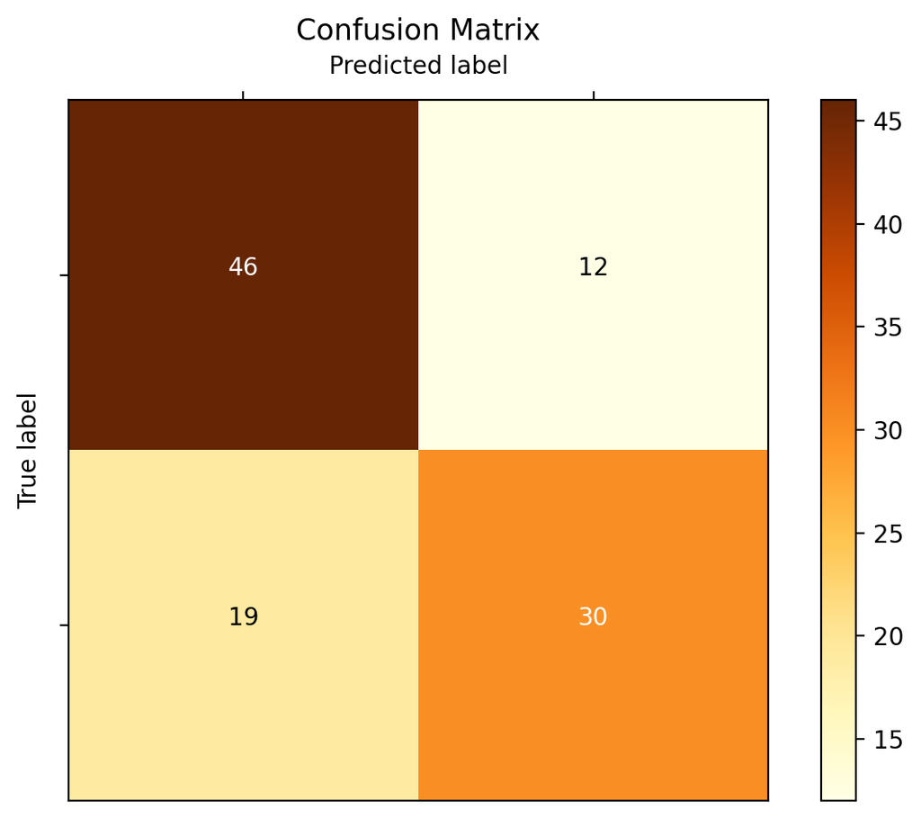

```python
from sklearn import tree
clf = DecisionTreeClassifier(random_state=SEED)
clf.fit(train, target)
predicted = clf.predict(test)
print("Accuracy:", metrics.accuracy_score(target_test, predicted))
print("Confusion Matrix: \n", metrics.confusion_matrix(target_test, predicted))
draw_confusion_matrix(target_test, predicted, ["", ""])
```

### 1.2. [2.5 pts] Visualize the Decision Tree

Visualize the first two layers of the decision tree that you trained.

```
[Text(0.5, 0.875, 'cat__cp_0 <= 0.5\ngini = 0.496\nsamples = 100.0%\nvalue = [0.546, 0.454]'),
```

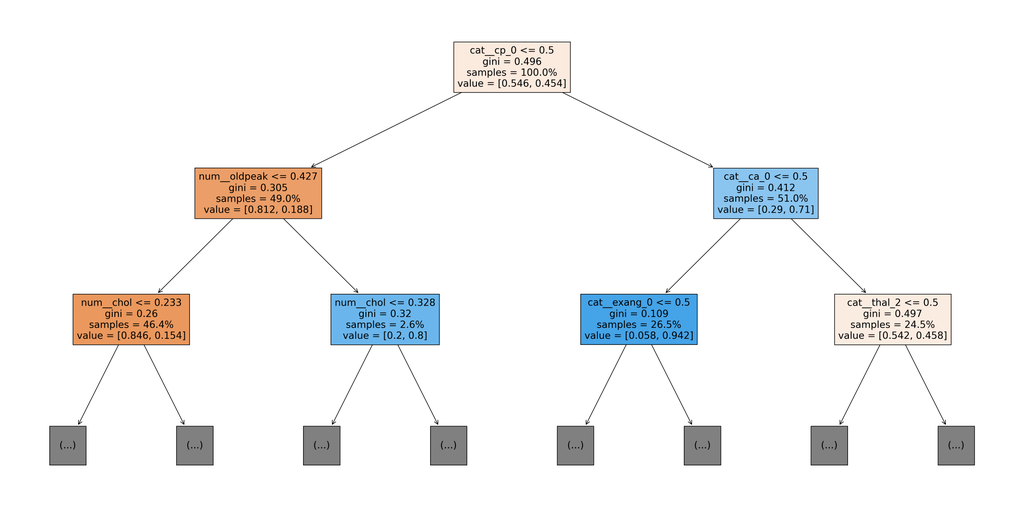

```python
plt.figure(figsize=(30, 15))
tree.plot_tree(
clf, max_depth=2, proportion=True, feature_names=feature_names, filled=True)
```

**What is the gini index improvement of the first split? Give an interpretation of the result**

```python
gini_index_improvement = (
    clf.tree_.impurity[0]
    - (clf.tree_.weighted_n_node_samples[1] / clf.tree_.weighted_n_node_samples[0]) * clf.tree_.impurity[1]
    - (clf.tree_.weighted_n_node_samples[2] / clf.tree_.weighted_n_node_samples[0]) * clf.tree_.impurity[2]
)

print(gini_index_improvement)
```

[output not shown]

### [2.5 pts] Plot the importance of each feature for the Decision Tree

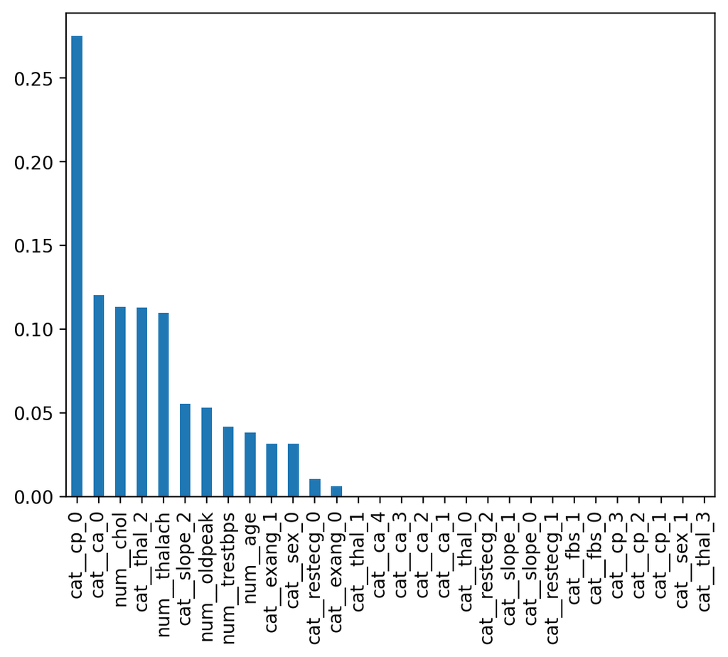

```python
imp_pd = pd.Series(data=clf.feature_importances_, index=feature_names)
imp_pd = imp_pd.sort_values(ascending=False)
imp_pd.plot.bar()
```

**How many features have non-zero importance for the Decision Tree? If we remove the features with zero importance, will it change the decision tree for the same sampled dataset?**

Response: There are 13 features with non-zero importance for the Decision tree. If we remove the features with zero importance, the decision tree will not change since we're using the same sampled dataset and random seed, so only the features with non--zero importance determine the splits.

### [7.5 pts] Optimize Decision Tree

While the default Decision Tree performs fairly well on the data, lets see if we can improve performance by optimizing the parameters.

Run a `GridSearchCV` with 5-Fold Cross Validation for the Decision Tree. Find the best model parameters for accuracy amongst the following:

- `max_depth` = [4, 8, 16, 32, 64]
- `min_samples_split` = [4, 8, 16, 32]
- `criterion` = [`gini`, `entropy`, `log_loss`]

After using `GridSearchCV`, Print the **best 10 models** with the following parameters: `rank_test_score`, `param_max_depth`, `param_min_samples_split`, `param_criterion`, `mean_test_score`, `std_test_score`.

```python
from sklearn.model_selection import GridSearchCV
from sklearn.tree import DecisionTreeClassifier
import pandas as pd

# Define the expanded parameter grid
param_grid = {
    'max_depth': [4, 8, 16, 32, 64],
    'min_samples_split': [4, 8, 16, 32],
    'criterion': ['gini', 'entropy', 'log_loss']
}

# Initialize Decision Tree classifier
clf = DecisionTreeClassifier(random_state=SEED)

# Run GridSearchCV with 5-fold CV and accuracy scoring
grid_search = GridSearchCV(clf, param_grid, cv=5, scoring='accuracy')
grid_search.fit(train, target)

# Extract and display the top 10 models
results = pd.DataFrame(grid_search.cv_results_)
best_models = results.nsmallest(10, 'rank_test_score')[[
    'rank_test_score', 'param_max_depth', 'param_min_samples_split',
    'param_criterion', 'mean_test_score', 'std_test_score'
]]

print(best_models)
```

```
    rank_test_score param_max_depth param_min_samples_split param_criterion  \
22                1               4                      16         entropy
42                1               4                      16        log_loss
4                 3               8                       4            gini
8                 3              16                       4            gini
12                3              32                       4            gini
16                3              64                       4            gini
26                7               8                      16         entropy
30                7              16                      16         entropy
34                7              32                      16         entropy
38                7              64                      16         entropy

    mean_test_score  std_test_score
22         0.754744        0.051454
42         0.754744        0.051454
4          0.739744        0.025512
8          0.739744        0.025512
12         0.739744        0.025512
16         0.739744        0.025512
26         0.739744        0.037945
30         0.739744        0.037945
34         0.739744        0.037945
38         0.739744        0.037945
```

**Using the best model you have, report the test accuracy and print out the confusion matrix**

```
Accuracy: 0.7850467289719626
Confusion Matrix:
 [[50  8]
 [15 34]]
```

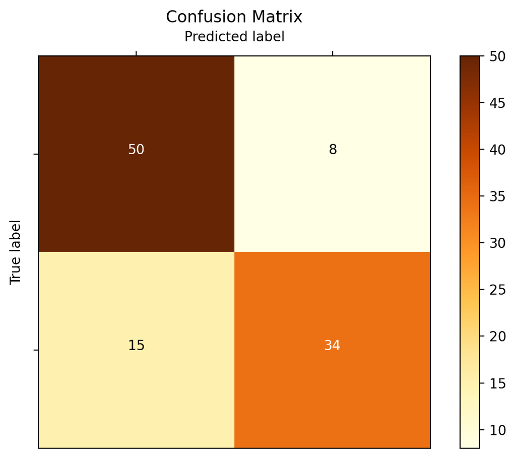

```python
# from sklearn.metrics import accuracy_score
best_model = grid_search.best_estimator_
predicted = best_model.predict(test)
print("Accuracy:", metrics.accuracy_score(target_test, predicted))
print("Confusion Matrix: \n", metrics.confusion_matrix(target_test, predicted))
draw_confusion_matrix(target_test, predicted, ["", ""])
```

## (10 pts) Multi-Layer Perceptron

### [2.5 pts] Applying a Multi-Layer Perceptron

Apply the MLP on the **train data** with hidden_layer_sizes=(100, 100) and max_iter = 1000. **Report the accuracy and print the confusion matrix**. Make sure to set `random_state=SEED`.

```
Train Accuracy: 1.0
Test Accuracy: 0.8317757009345794
Confusion Matrix:
 [[52  6]
 [12 37]]
```

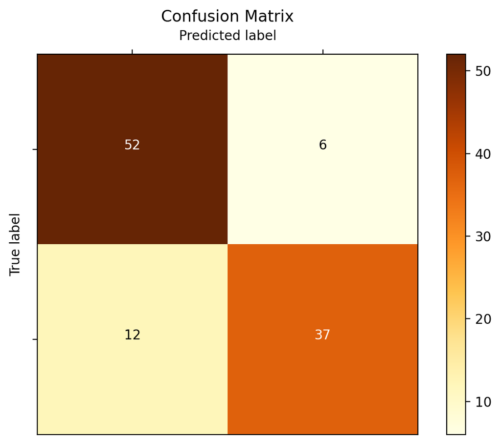

```python
mlp = MLPClassifier(hidden_layer_sizes=(100,100), max_iter=1000,
random_state=SEED)
mlp.fit(train, target)
10
y_train_pred = mlp.predict(train)
print("Train Accuracy:", metrics.accuracy_score(target, y_train_pred))
y_test_pred = mlp.predict(test)
print("Test Accuracy:", metrics.accuracy_score(target_test, y_test_pred))
print("Confusion Matrix: \n", metrics.confusion_matrix(target_test,
y_test_pred))
draw_confusion_matrix(target_test, y_test_pred, ["", ""])
```

### [5 pts] Speedtest between Decision Tree and MLP

Let us compare the training times and prediction times of a Decision Tree and an MLP. **Time how long it takes for a Decision Tree and an MLP to perform a .fit operation (i.e. training the model). Then, time how long it takes for a Decision Tree and an MLP to perform a .predict operation (i.e. predicting the testing data). Print out the timings and specify which model was quicker for each operation.** We recommend using the [time](https://docs.python.org/3/library/time.html) python module to time your code. An example of the time module was shown in project 2. Use the default Decision Tree Classifier and the MLP with the previously mentioned parameters.

```python
import time
from sklearn.tree import DecisionTreeClassifier
from sklearn.neural_network import MLPClassifier
dt = DecisionTreeClassifier(random_state=0)
mlp = MLPClassifier(hidden_layer_sizes=(100,100), max_iter=1000,
random_state=SEED)
start_time = time.time()
dt.fit(train, target)
dt_training_time = time.time() - start_time
start_time = time.time()
mlp.fit(train, target)
mlp_training_time = time.time() - start_time
start_time = time.time()
dt.predict(test)
dt_prediction_time = time.time() - start_time
start_time = time.time()
mlp.predict(test)
mlp_prediction_time = time.time() - start_time
print("Training Time for Decision Tree: {:.6f} sec".format(dt_training_time))
print("Training Time for MLP: {:.6f} sec".format(mlp_training_time))
print("Prediction Time for Decision Tree: {:.6f} sec".
format(dt_prediction_time))
print("Prediction Time for MLP: {:.6f} sec".format(mlp_prediction_time))
```

```
Training Time for Decision Tree: 0.003034 sec
Training Time for MLP: 0.396293 sec
Prediction Time for Decision Tree: 0.000274 sec
Prediction Time for MLP: 0.001241 sec
```

Response: Decision trees were quicker than MLPS for both training and prediction time.

### [2.5 pts] Compare and contrast Decision Trees and MLPs.

**Describe at least one advantage and disadvantage of using an MLP over a Decision Tree.**

Response: Using an MLP could be more advantageous since they can capture complex non-linear relationships more effectively, thanks to their flexible architecture with multiple layers and neurons. This makes them well-suited for high-dimensional data. However, a key drawback is that MLPs are more prone to overfitting and often require significantly more training time and computational resources compared to Decision Trees.

## (15 pts) PCA

### [2.5 pts] Transform the train data using PCA

Train a PCA model to project the train data on the top 8 components. **Print out the 8 principal components**. Look at the documentation of [PCA](https://scikit-learn.org/stable/modules/generated/sklearn.decomposition.PCA.html) for reference.

```python
pca = PCA(n_components=8)
pca.fit(train)
X_train_pca = pca.transform(train)
principal_components = pca.components_
print("Principal Components: ", principal_components)
```

```
Principal Components:  [[ 5.88824889e-02  3.60497119e-02  1.70206867e-02 -1.03789323e-01
   1.12949393e-01 -1.34058041e-01  1.34058041e-01  3.43838552e-01
  -1.49148921e-01 -1.90743643e-01 -3.94598830e-03 -1.77659035e-04
   1.77659035e-04  1.62590021e-01 -1.64229135e-01  1.63911390e-03
  -3.49296677e-01  3.49296677e-01  4.42573564e-02  2.98125292e-01
  -3.42382648e-01 -2.09179099e-01  8.88114413e-02  7.37523677e-02
   6.43314353e-02 -1.77161452e-02 -2.71173534e-04  4.76811068e-02
  -3.30445838e-01  2.83035904e-01]
 [ 6.13278432e-02  3.30647171e-02  3.82416019e-02 -1.28970449e-02
  -6.12059254e-04  4.16087229e-01 -4.16087229e-01  6.75333095e-02
  -2.01325731e-02 -4.83244503e-02  9.23713979e-04 -5.36809382e-02
   5.36809382e-02  4.76354860e-01 -4.90696705e-01  1.43418452e-02
   1.66001158e-02 -1.66001158e-02 -1.61815136e-02  1.26976371e-01
  -1.10794857e-01 -1.37704407e-02 -1.88951894e-02  5.13584946e-02
   9.62605522e-03 -2.83189197e-02  2.43409967e-03 -1.79759764e-03
   2.57549131e-01 -2.58185633e-01]
 [-4.30373267e-02 -3.36559313e-02  6.49260472e-03 -4.73583935e-02
   1.94009792e-02  3.32818332e-01 -3.32818332e-01  5.82053006e-02
   2.06697991e-02 -5.39898572e-02 -2.48852425e-02  1.88642130e-01
  -1.88642130e-01 -3.83618074e-01  3.61087011e-01  2.25310624e-02
  -9.47378849e-02  9.47378849e-02 -2.93911226e-02  3.73356525e-01
  -3.43965403e-01  3.06902783e-01 -1.90250785e-01 -6.09051989e-02
  -4.51949662e-02 -1.05518330e-02  4.18105418e-03 -1.36172655e-02
   4.48751539e-02 -3.54389426e-02]
 [-1.72735405e-02  5.28825152e-02  9.96363275e-03  4.71841404e-02
   3.21543406e-02 -1.28392814e-01  1.28392814e-01 -5.91001837e-02
   3.40025736e-02 -9.60286041e-02  1.21126214e-01  2.39879972e-02
  -2.39879972e-02  1.99845870e-01 -2.02181018e-01  2.33514831e-03
   3.89234783e-01 -3.89234783e-01  3.23208400e-02  1.67937182e-01
  -2.00258022e-01  3.90108929e-01 -4.04300020e-01 -1.03541209e-02
   3.73497862e-02 -1.28045745e-02  2.56300197e-03  5.58848629e-02
  -3.08111509e-01  2.49663644e-01]
 [ 7.47627151e-02  2.48266082e-02  4.04749115e-03 -4.42984136e-02
   1.99662995e-02  6.95875508e-02 -6.95875508e-02 -4.04735437e-01
  -7.10208393e-02  4.09316190e-01  6.64400859e-02 -2.15572063e-01
   2.15572063e-01 -8.05245268e-02  7.81944006e-02  2.33012622e-03
   1.94517362e-01 -1.94517362e-01 -5.96745297e-02  3.60779306e-01
  -3.01104776e-01 -3.66263814e-01  2.78404074e-01  3.95766679e-02
   1.83366074e-02  2.99464654e-02  7.32923906e-04 -5.92763654e-03
  -9.94055621e-02  1.04600275e-01]
```

[output cut: 9 more lines]

```
   2.42578740e-02  1.30401050e-01 -1.30401050e-01 -2.21396778e-01
  -4.35730066e-02  2.08860049e-01  5.61097361e-02 -4.27838082e-01
   4.27838082e-01  6.81235342e-03  1.17700683e-03 -7.98936025e-03
  -3.11279827e-01  3.11279827e-01  6.86037070e-02 -1.69803378e-01
   1.01199671e-01  3.47670519e-01 -2.64421539e-01 -3.72261070e-02
  -1.51708269e-02 -3.08520464e-02  3.09748886e-02 -4.13864056e-02
  -1.68707902e-01  1.79119419e-01]
 [ 2.97311833e-02  3.61033214e-02 -2.30771943e-02 -9.03087358e-03
   6.66062121e-03  5.09894872e-02 -5.09894872e-02  2.92850765e-01
   1.89291973e-01 -4.90145517e-01  8.00277937e-03 -4.10522690e-01
   4.10522690e-01 -2.01792583e-01  2.01558281e-01  2.34301568e-04
   1.69611142e-01 -1.69611142e-01 -4.21749517e-03  1.80916827e-02
  -1.38741875e-02 -1.99110630e-01 -1.15018374e-01  2.46470035e-01
   7.89518397e-02 -1.12928705e-02  2.40972758e-03  1.21356651e-01
   1.29577769e-02 -1.36724155e-01]]
```

### [2.5 pts] Percentage of variance explained by top 8 principal components

Using PCA's "explained_variance_ratio_", print the percentage of variance explained by the top 8 principal components.

```python
pca = PCA(n_components=8)
pca.fit(train)
explained_variance_ratio = pca.explained_variance_ratio_
print("Percentage of Variance Explained by Top 8 Principal Components:\n ",
explained_variance_ratio*100)
```

```
Percentage of Variance Explained by Top 8 Principal Components:
  [23.40265324 13.97151557 10.08586045  8.11110555  7.50913132  6.75425406
  5.99149126  4.95133091]
```

### [2.5 pts] Transform the train and test data into train_pca and test_pca using PCA

Note: Use fit_transform for train and transform for test

```python
pca = PCA(n_components=8)
train_pca = pca.fit_transform(train)
test_pca = pca.transform(test)
```

### [2.5 pts] PCA+Decision Tree

Train the default Decision Tree Classifier using train_pca. **Report the accuracy using test_pca and print the confusion matrix**.

```
Accuracy: 0.822429906542056
Confusion Matrix:
 [[51  7]
 [12 37]]
```

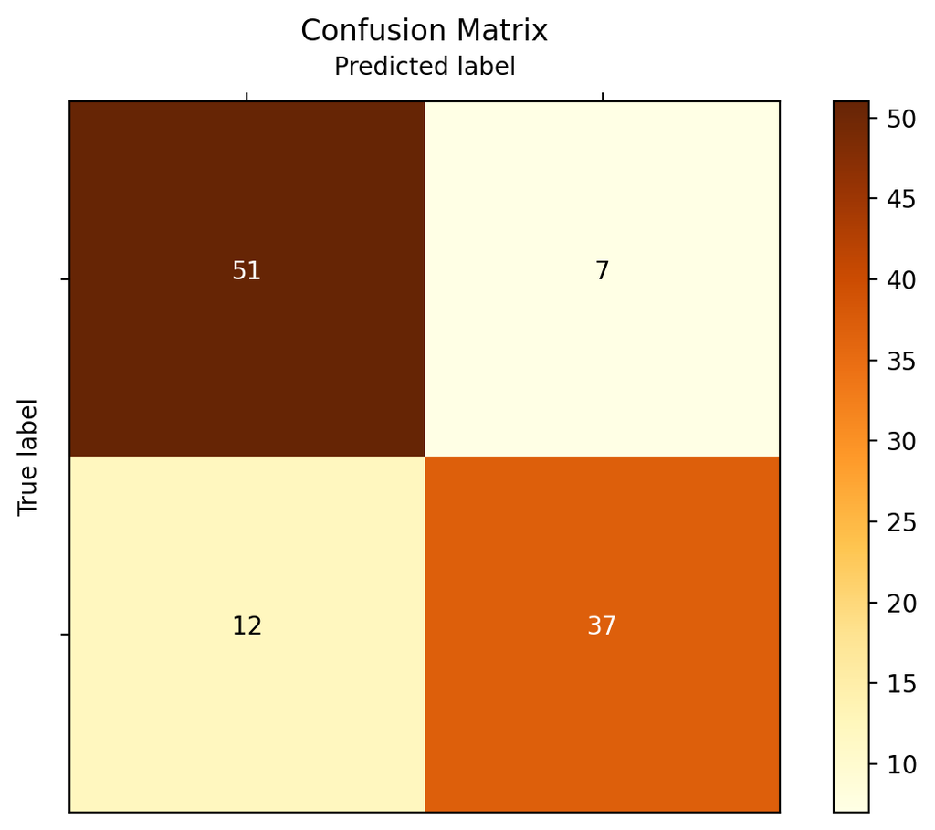

```python
dt_pca = DecisionTreeClassifier()
dt_pca.fit(train_pca, target)
accuracy = dt_pca.score(test_pca, target_test)
print("Accuracy:", accuracy)
15
y_pred = dt_pca.predict(test_pca)
print("Confusion Matrix: \n", metrics.confusion_matrix(target_test, y_pred))
draw_confusion_matrix(target_test, y_pred, ["", ""])
```

**Does the model perform better with or without PCA? Give an explanation**

Response: The model performs better with PCA, since PCA removes noise and reduces overfitting.

### [2.5 pts] PCA+MLP

Train the MLP classifier with the same parameters as before using train_pca. **Report the accuracy using test_pca and print the confusion matrix**.

```
Accuracy: 0.8130841121495327
Confusion Matrix:
 [[50  8]
 [12 37]]
```

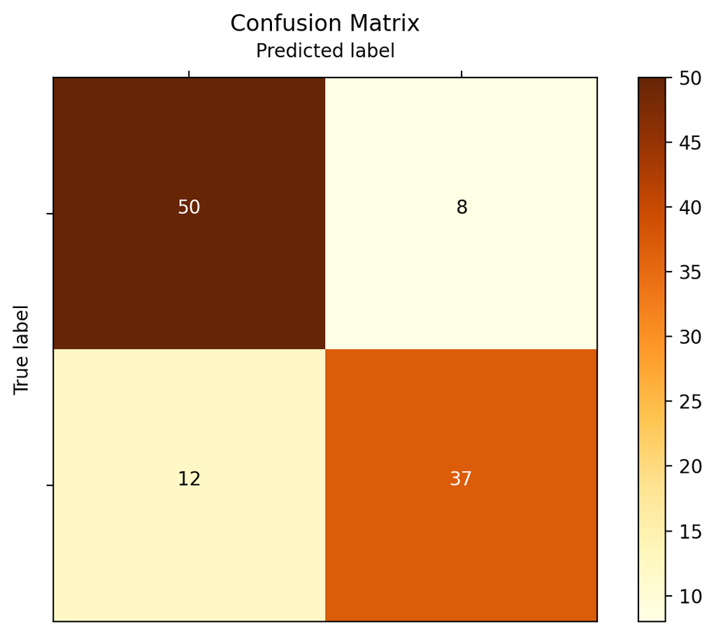

```python
mlp_pca = MLPClassifier(hidden_layer_sizes=(100,100), max_iter=1000,
random_state=SEED)
mlp_pca.fit(train_pca, target)
accuracy = mlp_pca.score(test_pca, target_test)
print("Accuracy:", accuracy)
y_pred = mlp_pca.predict(test_pca)
print("Confusion Matrix: \n", metrics.confusion_matrix(target_test, y_pred))
draw_confusion_matrix(target_test, y_pred, ["", ""])
```

**Does the model perform better with or without PCA? Give an explanation**

Response: It performed slightly worse with PCA. MLPs are good at handling high dimensional data, so reducing input features through PCA may not be as helpful if it removes useful variance.

### [2.5 pts] Pros and Cons of PCA

**In your own words, provide at least two pros and at least two cons for using PCA**

Response: Pros: PCA reduces the number of input features (dimensionality), which can help models avoid overfitting.

PCA removes redundancy and transforms correlated features into uncorrelated principal components, which can improve performance for models sensitive to multicollinearity.

Cons: After applying PCA, features are transformed into abstract components, which can lead to a loss of interpretability.

If too few components are retained, there is a risk of important variance in the data being lost.

## (10 pts) K-Means Clustering

### [2.5 pts] Apply K-means to the train data and print out the Inertia score

Use n_cluster = 15 and `random_state = SEED`.

```python
kmeans = KMeans(n_clusters=15, random_state=SEED)
kmeans.fit(train)
inertia_score = kmeans.inertia_
print("Inertia score:", inertia_score)
```

```
Inertia score: 385.51181909863436
```

### [5 pts] Find the optimal cluster size using the elbow method.

Use the elbow method to find the best cluster size or range of best cluster sizes for the train data. Check the cluster sizes from 2 to 30. Make sure to plot the Inertia and state where you think the elbow starts. Make sure to use `random_state = SEED`.

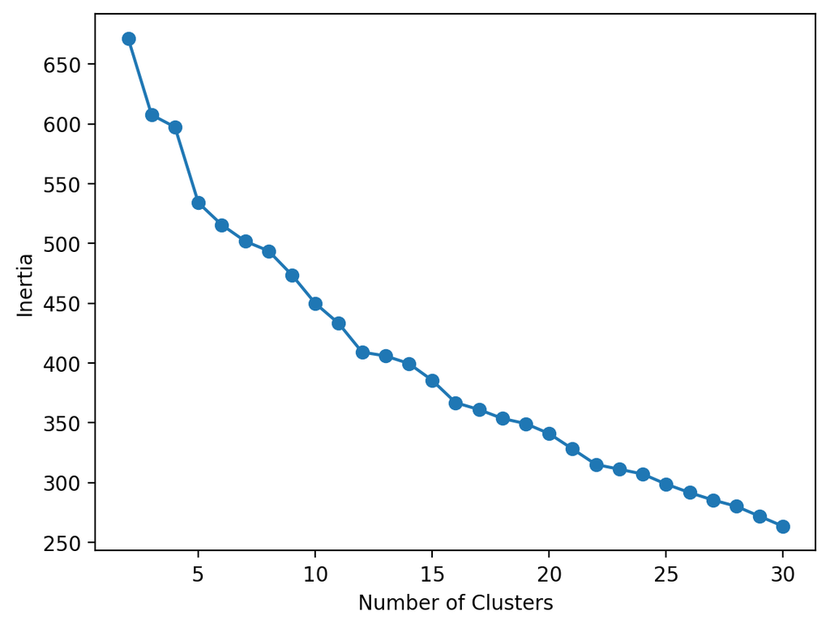

```python
inertia_scores = []
for k in range(2, 31):
    kmeans = KMeans(n_clusters=k, random_state=SEED)
    kmeans.fit(train)
    inertia_scores.append(kmeans.inertia_)
plt.plot(range(2, 31), inertia_scores, marker='o')
plt.xlabel('Number of Clusters')
plt.ylabel('Inertia')
plt.show()
```

**What seems to be the best range of cluster sizes?**

### [2.5 pts] Find the optimal cluster size for the train_pca data

Repeat the same experiment but use train_pca instead of train.

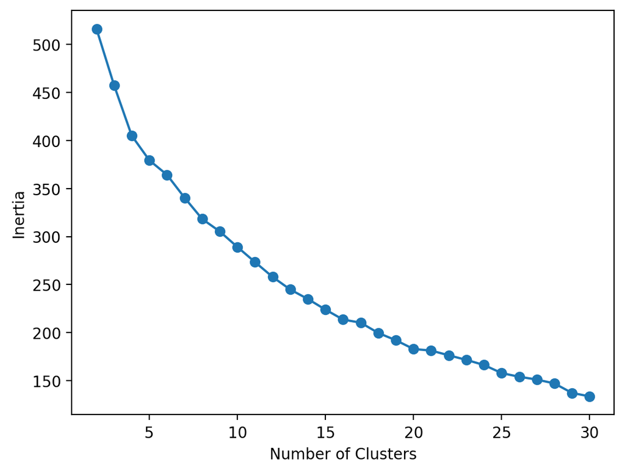

```python
inertia_scores = []
for k in range(2, 31):
    kmeans = KMeans(n_clusters=k, random_state=SEED)
    kmeans.fit(train_pca)
    inertia_scores.append(kmeans.inertia_)
plt.plot(range(2, 31), inertia_scores, marker='o')
plt.xlabel('Number of Clusters')
plt.ylabel('Inertia')
plt.show()
```

**What seems to be the best range of cluster sizes? Explain as well any differences between the resulting curve and the one from the previous exercise.**

Response: The elbow point is around 5-6 clusters, since after that the decrease is more gradual, making this the best range of cluster size. This curve is smoother and the elbow is clearer, likely because PCA reduced noise, making clusters more distinct.